# Loading and preprocessing the data

opts_chunk$set(echo=TRUE)

## Loading and preprocessing the data

```r
setwd("/Users/konggas")
activity <- read.csv("./activity.csv")
activity$datep <- strptime(activity$date,"%Y-%m-%d")
activity<-activity[order(activity$datep,activity$interval),]
```

## What is mean total number of steps taken per day?

```r
library("plyr")
act_day <- ddply(activity,~date,summarise,sum=sum(steps,na.rm=TRUE), mean=mean(steps,na.rm=TRUE), median=median(steps,na.rm=TRUE))
```

### Histogram of the total number of steps taken each day

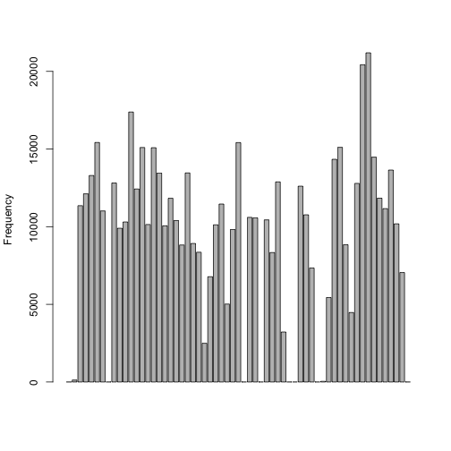

### Mean and median total number of steps taken per day

```r
print(act_day)
```

```
##          date   sum    mean median
## 1  2012-10-01     0     NaN     NA
## 2  2012-10-02   126  0.4375      0
## 3  2012-10-03 11352 39.4167      0
## 4  2012-10-04 12116 42.0694      0
## 5  2012-10-05 13294 46.1597      0
## 6  2012-10-06 15420 53.5417      0
## 7  2012-10-07 11015 38.2465      0
## 8  2012-10-08     0     NaN     NA
## 9  2012-10-09 12811 44.4826      0
## 10 2012-10-10  9900 34.3750      0
## 11 2012-10-11 10304 35.7778      0
## 12 2012-10-12 17382 60.3542      0
## 13 2012-10-13 12426 43.1458      0
## 14 2012-10-14 15098 52.4236      0
```

[output cut: 47 more lines]

## What is the average daily activity pattern?

```r
act_int <- ddply(activity,~interval,summarise,mean=mean(steps,na.rm=TRUE))
act_ts <- ts(act_int$mean)
```

### Time series plot of the 5-minute interval and the average number of steps taken, averaged across all days

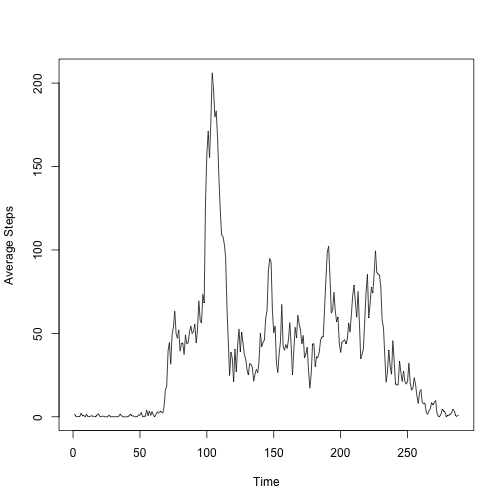

### Interval 835 (row=104) has the maximum average steps taken.

```r
act_int[which.max(act_int$mean),]
```

```
##     interval  mean
## 104      835 206.2
```

## Imputing missing values

### Ttal number of missing values in the dataset

```r
sum(is.na(activity$steps))
```

```
## [1] 2304
```

### Strategy for filling in all of the missing values in the dataset is using either left or right non-missing value

### New dataset that is equal to the original dataset but with the missing data filled in: act_imp

```r
fillin <- function(x) {
  for (i in 2:nrow(x)) {
    if (is.na(x[i,1]) == TRUE) {
      x[i,1] <- x[i-1,1]
    }
  }
  for (i in (nrow(x)-1):1) {
    if (is.na(x[i,1]) == TRUE) {
      x[i,1] <- x[i+1,1]
    }
  }
  x
}
act_imp<-fillin(activity)
```

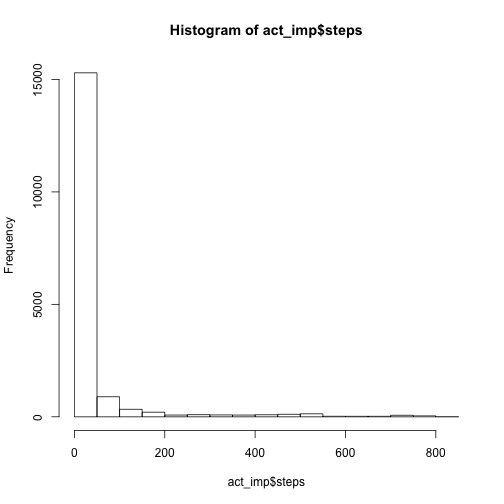

### Mean and median total number of steps taken per day

```r
act_day2 <- ddply(act_imp,~date,summarise,sum = sum(steps), mean=mean(steps,na.rm=TRUE),median=median(steps,na.rm=TRUE))

print(act_day2)
```

```
##          date   sum    mean median
## 1  2012-10-01     0  0.0000      0
## 2  2012-10-02   126  0.4375      0
## 3  2012-10-03 11352 39.4167      0
## 4  2012-10-04 12116 42.0694      0
## 5  2012-10-05 13294 46.1597      0
## 6  2012-10-06 15420 53.5417      0
## 7  2012-10-07 11015 38.2465      0
## 8  2012-10-08     0  0.0000      0
## 9  2012-10-09 12811 44.4826      0
## 10 2012-10-10  9900 34.3750      0
## 11 2012-10-11 10304 35.7778      0
## 12 2012-10-12 17382 60.3542      0
## 13 2012-10-13 12426 43.1458      0
## 14 2012-10-14 15098 52.4236      0
```

[output cut: 47 more lines]

## Are there differences in activity patterns between weekdays and weekends?

### Create a new factor variable in the dataset with two levels – “weekday” and “weekend” indicating whether a given date is a weekday or weekend day. And it is named as act_imp3

```r
act_imp2 <- act_imp
act_imp2$day <- weekdays(act_imp2$datep)
act_imp2$weekday<-""
weekday <- function(x) {
  res<-data.frame()
  for (i in 1:nrow(x)) {
    if (x[i,5] == "Sunday" || x[i,5] == "Saturday") {
      x[i,6] = "weekend";
    }
    else {
      x[i,6]="weekday";
    }
  }
  x
}
act_imp3<-weekday(act_imp2)
act_imp3$weekday <- as.factor(act_imp3$weekday)
```

### Panel plot containing a time series plot of the 5-minute interval and the average number of steps taken, averaged across all weekday days or weekend days

```r
act_week <- ddply(act_imp3,~interval+weekday,summarise,mean=mean(steps,na.rm=TRUE))

act_week1<-act_week[act_week$weekday=="weekday",c(1,3)]
act_week2<-act_week[act_week$weekday=="weekend",c(1,3)]
names(act_week1)[2]<- "weekday"
names(act_week2)[2]<- "weekend"

act_week_mer<-merge(act_week1,act_week2,by="interval")
act_week_mer<-act_week_mer[,c(2,3)]
act_ts <- ts(act_week_mer)
```

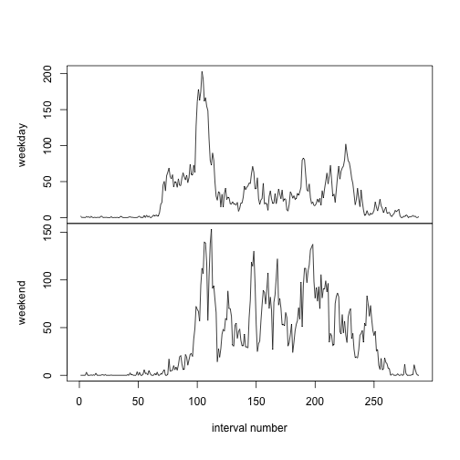